# Extreme Value Analysis - The Block Maxima Metod

Author

Alxandre Tribut

Published

July 22, 2024

# 1 Block Maxima extraction

We have a sample of wind speed for several years. To extract the block maximum, we define block of 1 year with the starting of the year on the 1st of July. If we would have taken the starting year on 1st of January, it would be more likely that we take the same storm for two consecutive years, as the big storms happen more in winter.

```r
bm <- BM_select(Cabauw_measure)
bm
```

```
# A tibble: 19 × 3
    year   max    ind
   <dbl> <dbl>  <int>
 1  2001  20.4  34632
 2  2002  25.9  69612
 3  2003  22.6 143102
 4  2004  18.4 185400
 5  2005  16.0 231637
 6  2006  22.6 291972
 7  2007  17.5 350635
 8  2008  19.3 388858
 9  2009  16.1 441013
10  2010  17.5 504920
11  2011  19.1 552783
12  2012  18.5 599824
13  2013  20.7 648350
14  2014  19.3 711566
15  2015  20.1 756405
16  2016  20.0 809492
17  2017  23.1 870534
18  2018  18.6 926279
19  2019  20.4 978857
```

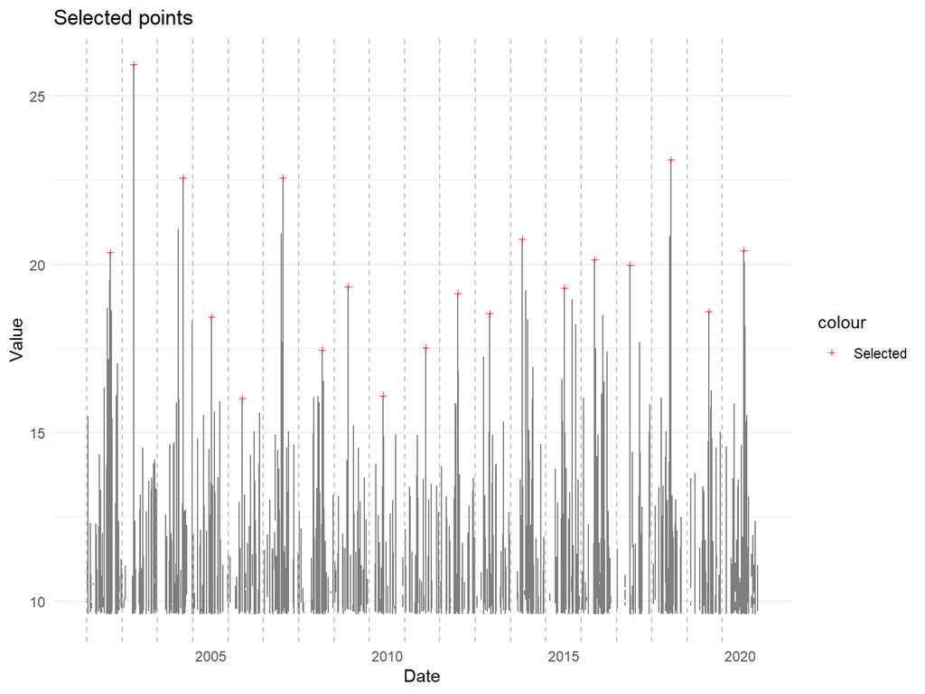

```r
plot_extremes(bm,data = Cabauw_measure,m='BM')
```

To see if our selection is good, we can look at the autocorrelation.

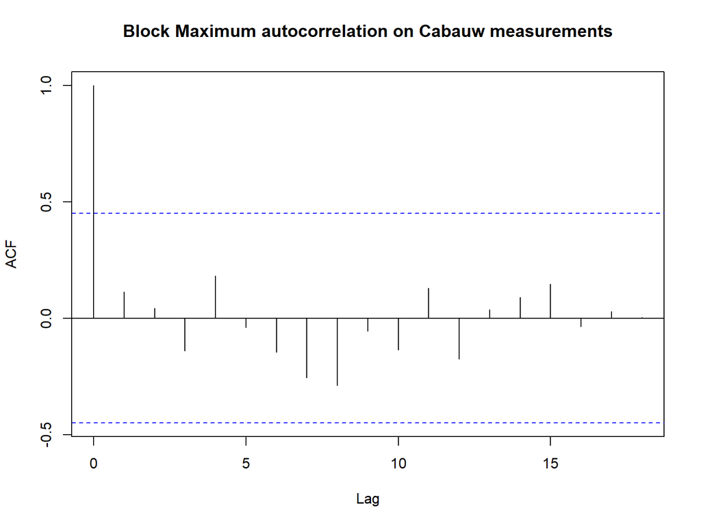

```r
acf(bm$max,lag.max = 2000,main = "Block Maximum autocorrelation on Cabauw measurements")
```

```r
Box.test(bm$max, type="Ljung-Box",fitdf = 3)
```

```
    Box-Ljung test

data:  bm$max
X-squared = 0.28389, df = -2, p-value = NA
```

So we can assume that the block maxima are independent.

# 2 Basic Block Maxima method for parameters estimation

To estimate parameters with Block Maxima method, we used the `fgev.flex` function with an assumption of stationarity in space and time. (space we take only one location and time we don’t take in account climate change) this function will fit the Generalized Extreme Value distribution the the Block Maxima sample.

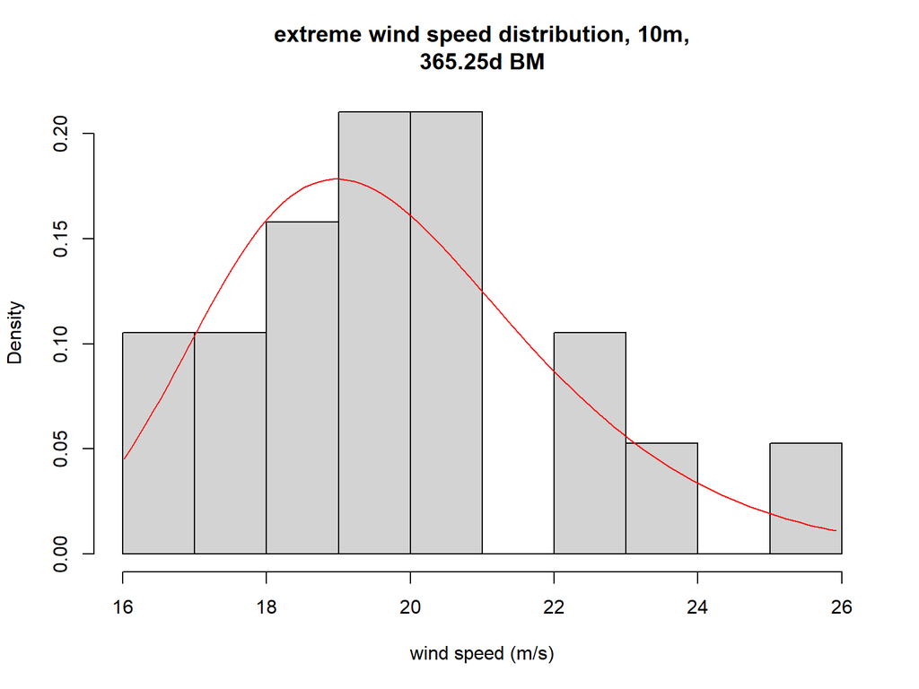

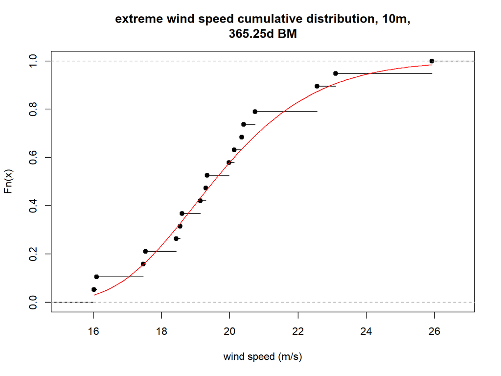

```r
trueTail = BM_fit(bm)
```

In black, we have the empirical distribution of the sample, and in red the estimated distribution.

# 3 Bootstrap for confidence interval

To estimate the confidence interval of the estimation, we can use the bootstrap method explained in report.

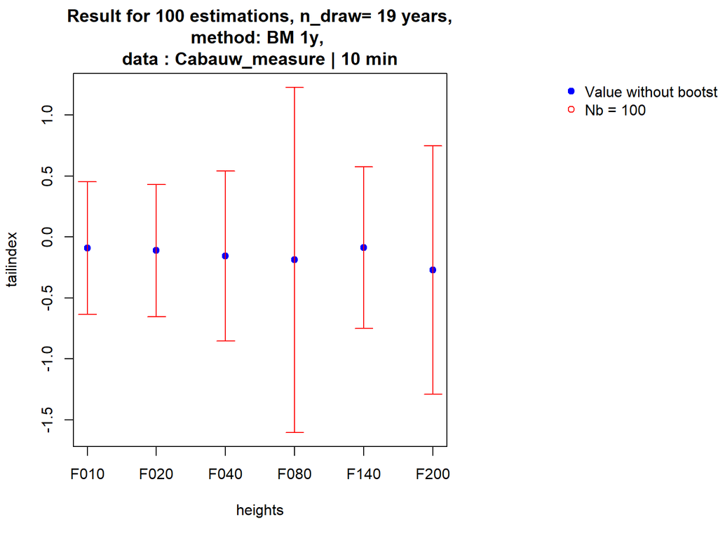

```r
BM_TIplot(Cabauw_measure,Nbs = 100)
```

On the measurements, because we don’t have many years of data, the uncertainties are big.

# 4 Wind speed estimation

Using this estimated parameters and there uncertainties, we can estimate the extrapolation of the distribution of the wind speed for high return period :

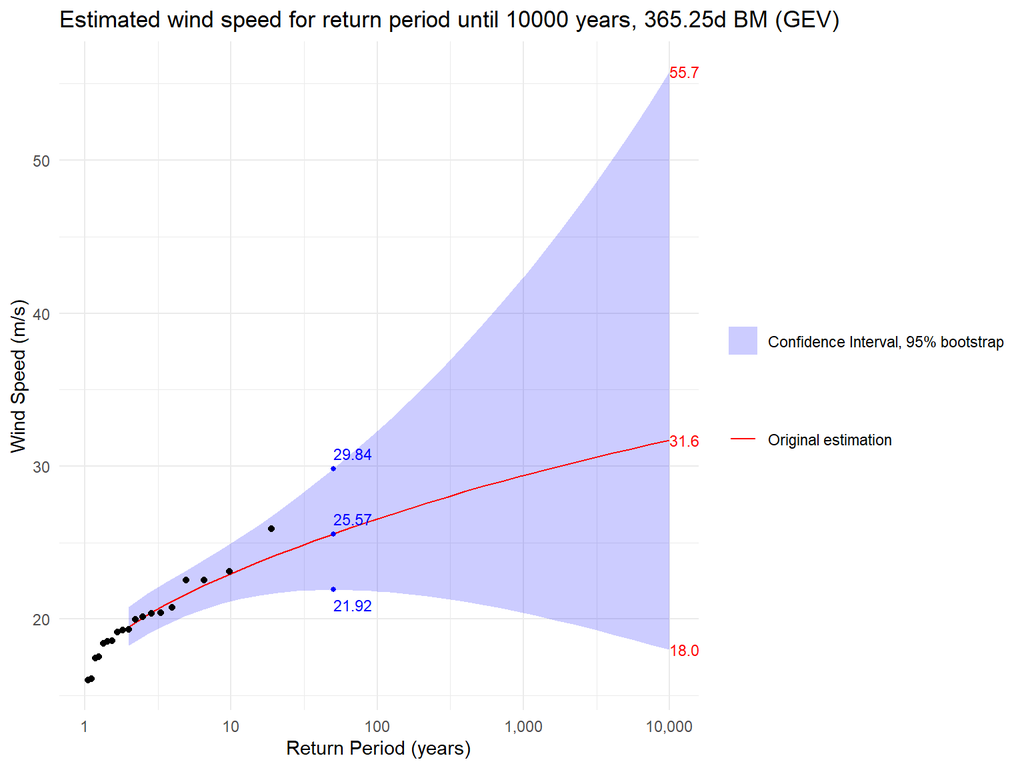

```r
out <- bootstrap(Cabauw_measure, Nb=500, column='F010', method='BM')
bm <- BM_select(Cabauw_measure)
trueTail <- BM_fit(bm,plot = F)
WSEst_BM(out,trueTail,bm=bm)
```

# 5 Independence of the estimations

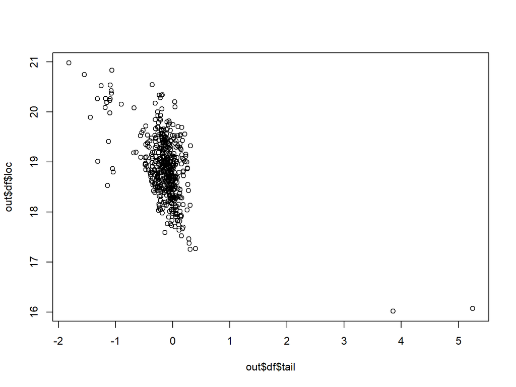

```r
plot(out$df$tail,out$df$loc)
```

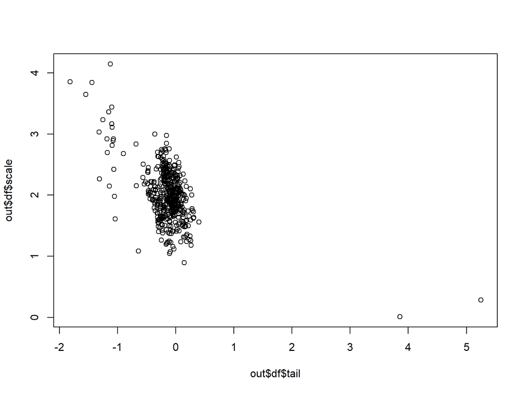

```r
plot(out$df$tail,out$df$scale)
```

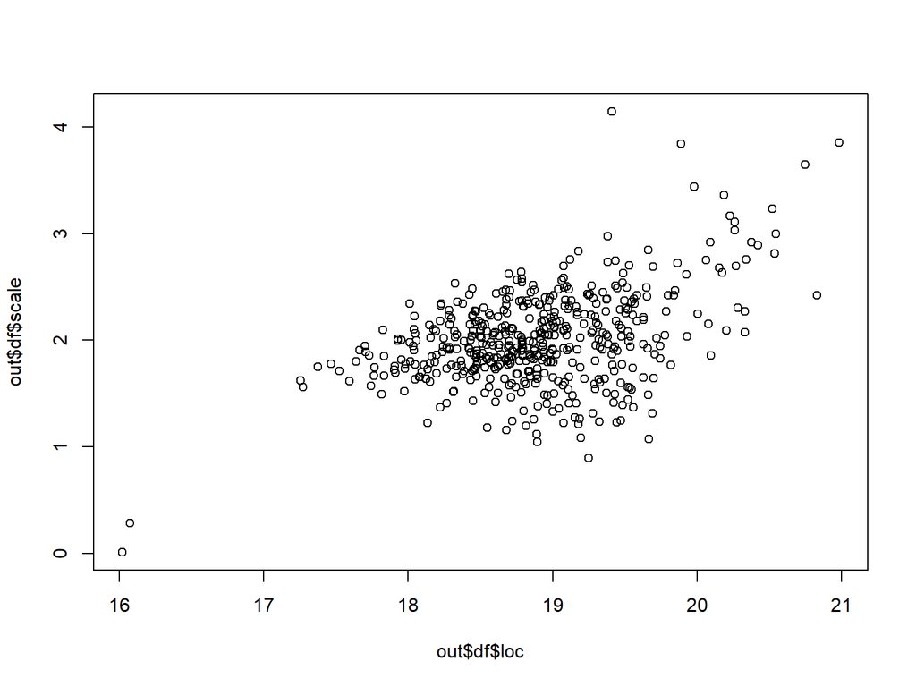

```r
plot(out$df$loc,out$df$scale)
```

```r
write.csv(out$df,file = "test.csv",dec = '.',sep=",",row.names = F)
```